# EWAS using different cell type references

## Download example data set

> Sen A, Cingolani P, Senut MC, Land S et al. Lead exposure induces changes in 5-hydroxymethylcytosine clusters in CpG islands in human embryonic stem cells and umbilical cord blood. Epigenetics 2015;10(7):607-21. PMID: 26046694

Retrieve the data from the Gene Expression Omnibus (GEO) website (http://www.ncbi.nlm.nih.gov/geo/query/acc.cgi?acc=GSE69633).

```r
download.450k.lead.dataset <- function() {
    dir.create(path <- "data-450k-lead")

    if (length(list.files(path, "*.idat$")) == 0) {
        filename <-  file.path(path, "gse69633.tar")
        download.file("http://www.ncbi.nlm.nih.gov/geo/download/?acc=GSE69633&format=file", filename)
        cat(date(), "Extracting files from GEO archive.\n")
        system(paste("cd", path, ";", "tar xvf", basename(filename)))
        unlink(filename)
        cat(date(), "Unzipping IDAT files.\n")
        system(paste("cd", path, ";", "gunzip *.idat.gz"))

        library(GEOquery)
        geo <- getGEO("GSE69633", GSEMatrix=F)
        ## this output from geo is really messed up.
        xx <- lapply(geo@gsms, function(x) x@header)
        characteristics <- t(sapply(xx, function(x) x$characteristics_ch1))
        colnames(characteristics) <- sub("([^:]+):.*", "\\1", characteristics[1,])
        rownames(characteristics) <- names(xx)
        characteristics <- apply(characteristics, 2, function(x) sub("[^:]+: (.*)", "\\1", x))
        characteristics <- as.data.frame(characteristics, stringsAsFactors=F)
        for (name in c("socioeconomic score", "gestational age", "birth weight", "pbconc (ng/dl)"))
            characteristics[[name]] <- as.numeric(characteristics[[name]])
        write.csv(characteristics, file=file.path(path, "samples.csv"))
    }

    path
}
```

```r
path <- download.450k.lead.dataset()
```

## Normalize dataset

Create samplesheet

```r
library(meffil)
options(mc.cores=5)
samplesheet <- meffil.create.samplesheet(path)

samples <- read.csv(file.path(path, "samples.csv"), check.names=F, row.names=1)
samplesheet <- data.frame(samplesheet,
                          samples[match(samplesheet$Sample_Name, rownames(samples)),],
                          stringsAsFactors=F, check.names=F)

samplesheet <- samplesheet[which(samplesheet[["sample type"]] == "HM450K"),]
```

Parameters.

```r
qc.file <- "cord/qc-report.html"
author <- "Sen, et al."
study <- "Cord blood DNA methylation and lead exposure (GSE69633)"
norm.file <- "cord/normalization-report.html"
cell.type.reference <- "gervin and lyle cord blood"
```

Generate QC objects for each sample and QC report.

```r
qc.objects <- meffil.qc(samplesheet, cell.type.reference=cell.type.reference, verbose=T)
```

```
## [read.idat] Thu Jun 24 23:41:10 2021 Reading data-450k-lead/GSM1704996_5815073001_R04C01_Grn.idat
## [read.idat] Thu Jun 24 23:41:10 2021 Reading data-450k-lead/GSM1704996_5815073001_R04C01_Red.idat
## [extract.detection.pvalues] Thu Jun 24 23:41:12 2021
## [extract.beadnum] Thu Jun 24 23:41:18 2021
## [extract.snp.betas] Thu Jun 24 23:41:20 2021
## [extract.controls] Thu Jun 24 23:41:20 2021
## [background.correct] Thu Jun 24 23:41:22 2021 background correction for dye = R
## [background.correct] Thu Jun 24 23:41:23 2021 background correction for dye = G
## [dye.bias.correct] Thu Jun 24 23:41:25 2021
## [FUN] Thu Jun 24 23:41:30 2021 predicting sex
```

```r
qc.summary <- meffil.qc.summary(qc.objects, verbose=T)
```

```
## [meffil.qc.summary] Thu Jun 24 23:44:11 2021 Sex summary TRUE
## [meffil.qc.summary] Thu Jun 24 23:44:11 2021 Meth vs unmeth summary
## [meffil.qc.summary] Thu Jun 24 23:44:11 2021 Control means summary
## [meffil.qc.summary] Thu Jun 24 23:44:11 2021 Sample detection summary
## [meffil.qc.summary] Thu Jun 24 23:44:13 2021 CpG detection summary
## [meffil.qc.summary] Thu Jun 24 23:44:13 2021 Sample bead numbers summary
## [meffil.qc.summary] Thu Jun 24 23:44:15 2021 CpG bead numbers summary
## [meffil.qc.summary] Thu Jun 24 23:44:16 2021 Cell count summary
## [meffil.qc.summary] Thu Jun 24 23:44:16 2021 Genotype concordance
```

```r
meffil.qc.report(qc.summary,
                 output.file=qc.file,
                 author=author,
                 study=study)
```

```
## [meffil.qc.report] Thu Jun 24 23:44:16 2021 Writing report as html file to cord/qc-report.html
```

Remove any low quality samples.

```r
if (nrow(qc.summary$bad.samples) > 0)
    qc.objects <- meffil.remove.samples(qc.objects, qc.summary$bad.samples$sample.name)

samplesheet <- samplesheet[match(names(qc.objects), rownames(samplesheet)),]
```

Check how many principal components to include.

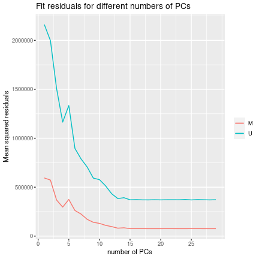

```r
print(meffil.plot.pc.fit(qc.objects, n.cross=3)$plot)
```

Ten seems about right.

```r
number.pcs <- 10
```

Normalize dataset and generate normalization report.

```r
norm.objects <- meffil.normalize.quantiles(qc.objects, number.pcs=number.pcs, verbose=T)
```

```
## [meffil.normalize.quantiles] Thu Jun 24 23:45:12 2021 selecting dye correction reference
## [meffil.normalize.quantiles] Thu Jun 24 23:45:12 2021 creating control matrix
## [meffil.normalize.quantiles] Thu Jun 24 23:45:12 2021 normalizing quantiles
## [FUN] Thu Jun 24 23:45:12 2021 genomic.iG M
## [FUN] Thu Jun 24 23:45:13 2021 genomic.iG U
## [FUN] Thu Jun 24 23:45:13 2021 genomic.iR M
## [FUN] Thu Jun 24 23:45:13 2021 genomic.iR U
## [FUN] Thu Jun 24 23:45:13 2021 genomic.ii M
## [FUN] Thu Jun 24 23:45:13 2021 genomic.ii U
## [FUN] Thu Jun 24 23:45:13 2021 autosomal.iG M
## [FUN] Thu Jun 24 23:45:13 2021 autosomal.iG U
## [FUN] Thu Jun 24 23:45:14 2021 autosomal.iR M
## [FUN] Thu Jun 24 23:45:14 2021 autosomal.iR U
## [FUN] Thu Jun 24 23:45:14 2021 autosomal.ii M
## [FUN] Thu Jun 24 23:45:14 2021 autosomal.ii U
## [FUN] Thu Jun 24 23:45:14 2021 not.y.iG M
## [FUN] Thu Jun 24 23:45:14 2021 not.y.iG U
## [FUN] Thu Jun 24 23:45:15 2021 not.y.iR M
## [FUN] Thu Jun 24 23:45:15 2021 not.y.iR U
## [FUN] Thu Jun 24 23:45:15 2021 not.y.ii M
## [FUN] Thu Jun 24 23:45:15 2021 not.y.ii U
## [FUN] Thu Jun 24 23:45:15 2021 sex M
## [FUN] Thu Jun 24 23:45:15 2021 sex U
## [FUN] Thu Jun 24 23:45:15 2021 chrx M
## [FUN] Thu Jun 24 23:45:15 2021 chrx U
## [FUN] Thu Jun 24 23:45:16 2021 chry M
## [FUN] Thu Jun 24 23:45:16 2021 chry U
```

```r
norm.dataset <- meffil.normalize.samples(norm.objects,
                                        just.beta=F,
                                        cpglist.remove=qc.summary$bad.cpgs$name,
                                        verbose=T)
```

```
## [read.idat] Thu Jun 24 23:45:16 2021 Reading data-450k-lead/GSM1704996_5815073001_R04C01_Grn.idat
## [read.idat] Thu Jun 24 23:45:16 2021 Reading data-450k-lead/GSM1704996_5815073001_R04C01_Red.idat
## [background.correct] Thu Jun 24 23:45:16 2021 background correction for dye = R
## [background.correct] Thu Jun 24 23:45:19 2021 background correction for dye = G
## [dye.bias.correct] Thu Jun 24 23:45:21 2021
## [meffil.normalize.sample] Thu Jun 24 23:45:23 2021 Normalizing methylated and unmethylated signals.
```

```r
beta <- meffil.get.beta(norm.dataset$M, norm.dataset$U)
pcs <- meffil.methylation.pcs(beta, sites=meffil.get.autosomal.sites("450k"), verbose=T)
```

```
## [meffil.methylation.pcs] Thu Jun 24 23:47:20 2021 Calculating CpG variance
## [meffil.methylation.pcs] Thu Jun 24 23:47:21 2021 Calculating beta PCs
```

```r
parameters <- meffil.normalization.parameters(norm.objects)
norm.summary <- meffil.normalization.summary(norm.objects=norm.objects,
                                             pcs=pcs,
                                             parameters=parameters, verbose=T)
```

```
## [meffil.plot.control.batch] Thu Jun 24 23:47:22 2021 Extracting batch variables
## [meffil.plot.control.batch] Thu Jun 24 23:47:22 2021 Testing associations
## [meffil.plot.probe.batch] Thu Jun 24 23:47:37 2021 Extracting batch variables
## [meffil.plot.probe.batch] Thu Jun 24 23:47:37 2021 Testing associations
```

```r
meffil.normalization.report(norm.summary,
                            output.file=norm.file,
                            author=author,
                            study=study)
```

```
## [meffil.normalization.report] Thu Jun 24 23:47:51 2021 Writing report as html file to cord/normalization-report.html
```

## Estimate cell counts using all available references

```r
counts <- sapply(meffil.list.cell.type.references(), function(reference) {
    cat(date(), reference, "\n")
    do.call(rbind, mclapply(qc.objects, function(qc.object) {
        meffil.estimate.cell.counts(qc.object, cell.type.reference=reference)$counts
    }))
}, simplify=F)
```

```
## Thu Jun 24 23:50:43 2021 andrews and bakulski cord blood
## Thu Jun 24 23:52:01 2021 blood gse35069
## Thu Jun 24 23:53:17 2021 blood gse35069 chen
## Thu Jun 24 23:54:37 2021 blood gse35069 complete
## Thu Jun 24 23:56:11 2021 combined cord blood
## Thu Jun 24 23:57:33 2021 cord blood gse68456
## Thu Jun 24 23:59:03 2021 gervin and lyle cord blood
## Fri Jun 25 00:00:28 2021 guintivano dlpfc
## Fri Jun 25 00:01:48 2021 saliva gse48472
```

## Compare counts between references

```r
r <- sapply(names(counts), function(n1)
       sapply(names(counts), function(n2) {
           sapply(intersect(colnames(counts[[n1]]), colnames(counts[[n2]])),
                  function(type) cor(counts[[n1]][,type], counts[[n2]][,type]))
       }))
```

```r
types <- unique(unlist(lapply(counts, function(counts) colnames(counts))))
for (type in types) {
    cat("Cell type", type, "-----------------\n")
    for (n1 in colnames(r))
        for (n2 in rownames(r))
            if (n1 < n2 && type %in% names(r[n1,n2][[1]]))
                cat(r[n1,n2][[1]][[type]], n1, "--", n2, "\n")
}
```

```
## Cell type Bcell -----------------
## 0.7320961 andrews and bakulski cord blood -- blood gse35069
## 0.6882443 andrews and bakulski cord blood -- blood gse35069 chen
## 0.7388463 andrews and bakulski cord blood -- blood gse35069 complete
## 0.9178149 andrews and bakulski cord blood -- combined cord blood
## 0.9222809 andrews and bakulski cord blood -- cord blood gse68456
## 0.6286834 andrews and bakulski cord blood -- gervin and lyle cord blood
## 0.7468512 andrews and bakulski cord blood -- saliva gse48472
## 0.6572276 blood gse35069 -- blood gse35069 chen
## 0.99326 blood gse35069 -- blood gse35069 complete
## 0.6715125 blood gse35069 -- combined cord blood
## 0.4985467 blood gse35069 -- cord blood gse68456
## 0.9619068 blood gse35069 -- gervin and lyle cord blood
## 0.9924158 blood gse35069 -- saliva gse48472
## 0.6913443 blood gse35069 chen -- blood gse35069 complete
## 0.6471715 blood gse35069 chen -- combined cord blood
## 0.6247752 blood gse35069 chen -- cord blood gse68456
## 0.6229087 blood gse35069 chen -- gervin and lyle cord blood
## 0.662963 blood gse35069 chen -- saliva gse48472
## 0.6823433 blood gse35069 complete -- combined cord blood
## 0.5056697 blood gse35069 complete -- cord blood gse68456
## 0.9667665 blood gse35069 complete -- gervin and lyle cord blood
## 0.9933404 blood gse35069 complete -- saliva gse48472
## 0.9032156 combined cord blood -- cord blood gse68456
## 0.5587003 combined cord blood -- gervin and lyle cord blood
## 0.6866336 combined cord blood -- saliva gse48472
## 0.370461 cord blood gse68456 -- gervin and lyle cord blood
## 0.5110402 cord blood gse68456 -- saliva gse48472
## 0.9541537 gervin and lyle cord blood -- saliva gse48472
## Cell type CD4T -----------------
## 0.8493954 andrews and bakulski cord blood -- blood gse35069
## 0.8052387 andrews and bakulski cord blood -- blood gse35069 chen
## 0.8586418 andrews and bakulski cord blood -- blood gse35069 complete
## 0.9431329 andrews and bakulski cord blood -- combined cord blood
## 0.948346 andrews and bakulski cord blood -- cord blood gse68456
## 0.8140324 andrews and bakulski cord blood -- gervin and lyle cord blood
## 0.895356 andrews and bakulski cord blood -- saliva gse48472
## 0.8406206 blood gse35069 -- blood gse35069 chen
## 0.9906903 blood gse35069 -- blood gse35069 complete
## 0.8099946 blood gse35069 -- combined cord blood
```

[output cut: 110 more lines]

```
## 0.8290412 combined cord blood -- saliva gse48472
## 0.5843128 cord blood gse68456 -- gervin and lyle cord blood
## 0.6448506 cord blood gse68456 -- saliva gse48472
## 0.9434688 gervin and lyle cord blood -- saliva gse48472
## Cell type nRBC -----------------
## 0.9661001 andrews and bakulski cord blood -- combined cord blood
## Cell type Eos -----------------
## 0.5802125 blood gse35069 chen -- blood gse35069 complete
## Cell type Neu -----------------
## 0.9656465 blood gse35069 chen -- blood gse35069 complete
## Cell type RBC -----------------
## Cell type CD14 -----------------
## Cell type NeuN_neg -----------------
## Cell type NeuN_pos -----------------
## Cell type Buccal -----------------
```

## Variables of interest

We will test associations with gender, gestational age, birth weight and blood lead levels. The following list provides the names of potential confounders to be included in EWAS regression models.

```r
covariate.names <- list("gender"=c("socioeconomic score","gestational age","smoke ever","birth weight"),
                        "gestational age"=c("socioeconomic score","gender","smoke ever","birth weight"),
                        "birth weight"=c("socioeconomic score","gestational age","smoke ever","gender"),
                        "pbconc (ng/dl)"=c("socioeconomic score","gestational age","smoke ever","birth weight","gender"))
```

For the gender EWAS, we will test only CpG sites on autosomes.

```r
features <- meffil.featureset("450k")
autosomal <- features[which(!(features$chromosome %in% c("chrX","chrY"))),]
```

## Test associations

Test associations for each variable of interest (4) and each cell type reference.

```r
results <- sapply(names(covariate.names), function(variable.name) {
    variable <- samplesheet[[variable.name]]
    sapply(names(counts), function(reference) {
        covariates <- data.frame(counts[[reference]],
                                 samplesheet[,covariate.names[[variable.name]]],
                                 stringsAsFactors=F)
        cat(date(), "ewas", variable.name, reference, "\n")
        if (variable.name == "gender")
            beta <- beta[which(rownames(beta) %in% autosomal$name),]
        meffil.ewas(beta, variable=variable, covariates=covariates,
                    isva=F, sva=F, smartsva=T,
                    most.variable=50000,verbose=T)
    }, simplify=F)
}, simplify=F)
```

```
## Fri Jun 25 00:03:13 2021 ewas gender andrews and bakulski cord blood
## [meffil.ewas] Fri Jun 25 00:03:14 2021 Simplifying any categorical variables.
## [meffil.ewas] Fri Jun 25 00:03:14 2021 Removing 0 missing case(s).
## [meffil.ewas] Fri Jun 25 00:03:14 2021 Removing 0 covariates with no variance.
## [meffil.ewas] Fri Jun 25 00:03:14 2021 Computing surrogate variables ...
## [add.surrogate.variables] Fri Jun 25 00:03:14 2021 Calculating CpG variance
## [add.surrogate.variables] Fri Jun 25 00:03:51 2021 smartSVA.
##
## [meffil.ewas] Fri Jun 25 00:04:00 2021 Starting EWAS ...
## [:::] [meffil] [ewas.by.matrix] Fri Jun 25 00:04:01 2021 Handling methylation outliers
## [FUN] Fri Jun 25 00:04:28 2021 EWAS for covariate set none
## [:::] [meffil] [ewas.limma] Fri Jun 25 00:04:28 2021 Linear regression with limma::lmFit
## [:::] [meffil] [ewas.limma] Fri Jun 25 00:04:28 2021 Linear regression with only fixed effects
## [:::] [meffil] [ewas.limma] Fri Jun 25 00:04:33 2021 Empirical Bayes
## [FUN] Fri Jun 25 00:04:45 2021 EWAS for covariate set all
## [:::] [meffil] [ewas.limma] Fri Jun 25 00:04:45 2021 Linear regression with limma::lmFit
## [:::] [meffil] [ewas.limma] Fri Jun 25 00:04:45 2021 Linear regression with only fixed effects
## [:::] [meffil] [ewas.limma] Fri Jun 25 00:04:48 2021 Empirical Bayes
## [FUN] Fri Jun 25 00:05:04 2021 EWAS for covariate set smartsva
## [:::] [meffil] [ewas.limma] Fri Jun 25 00:05:04 2021 Linear regression with limma::lmFit
## [:::] [meffil] [ewas.limma] Fri Jun 25 00:05:04 2021 Linear regression with only fixed effects
## [:::] [meffil] [ewas.limma] Fri Jun 25 00:05:11 2021 Empirical Bayes
## [meffil.ewas] Fri Jun 25 00:05:47 2021 Finished EWAS.
## Fri Jun 25 00:05:47 2021 ewas gender blood gse35069
## [meffil.ewas] Fri Jun 25 00:05:48 2021 Simplifying any categorical variables.
## [meffil.ewas] Fri Jun 25 00:05:48 2021 Removing 0 missing case(s).
## [meffil.ewas] Fri Jun 25 00:05:48 2021 Removing 0 covariates with no variance.
## [meffil.ewas] Fri Jun 25 00:05:48 2021 Computing surrogate variables ...
## [add.surrogate.variables] Fri Jun 25 00:05:49 2021 Calculating CpG variance
## [add.surrogate.variables] Fri Jun 25 00:06:25 2021 smartSVA.
##
## [meffil.ewas] Fri Jun 25 00:06:31 2021 Starting EWAS ...
## [:::] [meffil] [ewas.by.matrix] Fri Jun 25 00:06:31 2021 Handling methylation outliers
## [FUN] Fri Jun 25 00:07:00 2021 EWAS for covariate set none
## [:::] [meffil] [ewas.limma] Fri Jun 25 00:07:00 2021 Linear regression with limma::lmFit
## [:::] [meffil] [ewas.limma] Fri Jun 25 00:07:00 2021 Linear regression with only fixed effects
## [:::] [meffil] [ewas.limma] Fri Jun 25 00:07:01 2021 Empirical Bayes
## [FUN] Fri Jun 25 00:07:08 2021 EWAS for covariate set all
## [:::] [meffil] [ewas.limma] Fri Jun 25 00:07:08 2021 Linear regression with limma::lmFit
## [:::] [meffil] [ewas.limma] Fri Jun 25 00:07:08 2021 Linear regression with only fixed effects
```

[output cut: 773 more lines]

```
## [meffil.ewas] Fri Jun 25 01:05:46 2021 Starting EWAS ...
## [:::] [meffil] [ewas.by.matrix] Fri Jun 25 01:05:46 2021 Handling methylation outliers
## [FUN] Fri Jun 25 01:06:07 2021 EWAS for covariate set none
## [:::] [meffil] [ewas.limma] Fri Jun 25 01:06:07 2021 Linear regression with limma::lmFit
## [:::] [meffil] [ewas.limma] Fri Jun 25 01:06:07 2021 Linear regression with only fixed effects
## [:::] [meffil] [ewas.limma] Fri Jun 25 01:06:08 2021 Empirical Bayes
## [FUN] Fri Jun 25 01:06:14 2021 EWAS for covariate set all
## [:::] [meffil] [ewas.limma] Fri Jun 25 01:06:14 2021 Linear regression with limma::lmFit
## [:::] [meffil] [ewas.limma] Fri Jun 25 01:06:14 2021 Linear regression with only fixed effects
## [:::] [meffil] [ewas.limma] Fri Jun 25 01:06:16 2021 Empirical Bayes
## [FUN] Fri Jun 25 01:06:26 2021 EWAS for covariate set smartsva
## [:::] [meffil] [ewas.limma] Fri Jun 25 01:06:26 2021 Linear regression with limma::lmFit
## [:::] [meffil] [ewas.limma] Fri Jun 25 01:06:26 2021 Linear regression with only fixed effects
## [:::] [meffil] [ewas.limma] Fri Jun 25 01:06:31 2021 Empirical Bayes
## [meffil.ewas] Fri Jun 25 01:06:55 2021 Finished EWAS.
```

## Previously identified associations

For generating the EWAS reports, previously identified associations are provided for comparison with previous analyses. Only the lead (“pbconc”) list of associations is from the dataset used here.

```r
published.hits <- list("gender"=c("cg03691818", "cg26921482", "cg17743279", "cg07852945", "cg26355737", "cg25568337", "cg05100634", "cg03608000", "cg02325951", "cg17612569", "cg04874129", "cg08906898", "cg04946709", "cg02989351", "cg12204423", "cg25304146", "cg22345911", "cg01906879", "cg06152526", "cg04190002", "cg06644124", "cg07628841", "cg23001456", "cg26213873", "cg25438440", "cg07816873", "cg24016844", "cg11841231", "cg13323902", "cg12900929"), ## PMID: 26553366 (top 30)
                       "gestational age"=c("cg08943494", "cg11932158", "cg16725984", "cg20334115", "cg18623216", "cg07835443", "cg00220721", "cg04685228", "cg16103712", "cg27518892", "cg22117805", "cg21926626", "cg04347477", "cg08817867", "cg27448161", "cg01154283", "cg02001279", "cg02430430", "cg06870470", "cg13924996", "cg07136133", "cg00481600", "cg13675859", "cg11934771", "cg19744173", "cg12713583", "cg11360522", "cg16834726", "cg18608055", "cg05283597"), ## PMID: 25869828 (top 30)
                       "birth weight"=c("cg20076442", "cg25953130", "cg04521626", "cg14097568", "cg17133774", "cg00654448", "cg00442282", "cg13696490", "cg12044213", "cg08817867", "cg00382138", "cg06870470", "cg25557739", "cg24324628", "cg15783941", "cg14597739", "cg22962123", "cg05851442", "cg23387597", "cg24973755", "cg16219283", "cg25799241", "cg06658067"), ## PMID: 25869828 (bonferroni p < 0.05)
                       "pbconc (ng/dl)"=c("cg01105385", "cg07208333", "cg08945395", "cg20439288", "cg20474370"))## PMID: 26046694, all sites in chr5:67584213-67584451
```

## EWAS reports

```r
for (variable.name in names(results)) {
    for (reference in names(results[[variable.name]])) {
        cat(date(), "EWAS report", variable.name, reference, "\n")

        ewas.ret <- results[[variable.name]][[reference]]

        ewas.parameters <- meffil.ewas.parameters(max.plots=10)

        ewas.summary <- meffil.ewas.summary(ewas.ret,
                                            beta,
                                            selected.cpg.sites=published.hits[[variable.name]],
                                            parameters=ewas.parameters, verbose=T)
        meffil.ewas.report(ewas.summary,
                           output.file=file.path("cord", sub(" \\(.*", "", variable.name),
                               reference, "report.html"),
                           author="Me",
                           study=paste(variable.name,
                               " in cord blood DNA methylation (GEO:GSE69633)",
                               " adjusted with the '", reference, "' cell type reference.", sep=""))
    }
}
```

## Association overlaps between different analyses

Show size of overlap between analyses using different cell type references. For each, we use the results obtained using confounders obtained using “smartsva” (all potential confounders listed above plus surrogate variables).

```r
compare.top <- function(results, top=100, method) {
    sites <- lapply(results, function(ewas) {
        idx <- order(ewas$p.value[,method], decreasing=F)[1:top]
        rownames(ewas$p.value)[idx]
    })
    sapply(sites, function(x) sapply(sites, function(y) length(intersect(x,y))))
}
comparison.table <- function(results, method) {
    comparisons <- lapply(results, compare.top, method=method)
    for (name in names(results)) {
        comparisons[[name]] <- as.data.frame(comparisons[[name]])
        comparisons[[name]]$reference <- rownames(comparisons[[name]])
        comparisons[[name]]$variable <- name
    }
    comparisons <- do.call(rbind, comparisons)
}
knitr:::kable(comparison.table(results, "smartsva"), row.names=F)
```

| andrews and bakulski cord blood | blood gse35069 | blood gse35069 chen | blood gse35069 complete | combined cord blood | cord blood gse68456 | gervin and lyle cord blood | guintivano dlpfc | saliva gse48472 | reference | variable |
| --- | --- | --- | --- | --- | --- | --- | --- | --- | --- | --- |
| 100 | 10 | 3 | 7 | 8 | 6 | 7 | 10 | 5 | andrews and bakulski cord blood | gender |
| 10 | 100 | 2 | 17 | 9 | 8 | 7 | 14 | 12 | blood gse35069 | gender |
| 3 | 2 | 100 | 2 | 3 | 3 | 3 | 6 | 2 | blood gse35069 chen | gender |
| 7 | 17 | 2 | 100 | 8 | 8 | 14 | 12 | 14 | blood gse35069 complete | gender |
| 8 | 9 | 3 | 8 | 100 | 4 | 4 | 8 | 4 | combined cord blood | gender |
| 6 | 8 | 3 | 8 | 4 | 100 | 5 | 7 | 6 | cord blood gse68456 | gender |
| 7 | 7 | 3 | 14 | 4 | 5 | 100 | 15 | 7 | gervin and lyle cord blood | gender |
| 10 | 14 | 6 | 12 | 8 | 7 | 15 | 100 | 9 | guintivano dlpfc | gender |
| 5 | 12 | 2 | 14 | 4 | 6 | 7 | 9 | 100 | saliva gse48472 | gender |
| 100 | 2 | 0 | 2 | 0 | 0 | 0 | 3 | 0 | andrews and bakulski cord blood | gestational age |
| 2 | 100 | 0 | 17 | 0 | 4 | 0 | 5 | 4 | blood gse35069 | gestational age |
| 0 | 0 | 100 | 0 | 0 | 0 | 0 | 1 | 0 | blood gse35069 chen | gestational age |
| 2 | 17 | 0 | 100 | 1 | 3 | 1 | 3 | 3 | blood gse35069 complete | gestational age |
| 0 | 0 | 0 | 1 | 100 | 0 | 0 | 0 | 0 | combined cord blood | gestational age |
| 0 | 4 | 0 | 3 | 0 | 100 | 1 | 2 | 0 | cord blood gse68456 | gestational age |
| 0 | 0 | 0 | 1 | 0 | 1 | 100 | 0 | 0 | gervin and lyle cord blood | gestational age |
| 3 | 5 | 1 | 3 | 0 | 2 | 0 | 100 | 1 | guintivano dlpfc | gestational age |
| 0 | 4 | 0 | 3 | 0 | 0 | 0 | 1 | 100 | saliva gse48472 | gestational age |
| 100 | 0 | 0 | 0 | 0 | 1 | 3 | 2 | 0 | andrews and bakulski cord blood | birth weight |
| 0 | 100 | 0 | 1 | 0 | 0 | 0 | 0 | 0 | blood gse35069 | birth weight |
| 0 | 0 | 100 | 0 | 0 | 0 | 0 | 0 | 0 | blood gse35069 chen | birth weight |
| 0 | 1 | 0 | 100 | 0 | 1 | 0 | 1 | 0 | blood gse35069 complete | birth weight |
| 0 | 0 | 0 | 0 | 100 | 0 | 0 | 0 | 1 | combined cord blood | birth weight |
| 1 | 0 | 0 | 1 | 0 | 100 | 0 | 0 | 0 | cord blood gse68456 | birth weight |
| 3 | 0 | 0 | 0 | 0 | 0 | 100 | 1 | 0 | gervin and lyle cord blood | birth weight |
| 2 | 0 | 0 | 1 | 0 | 0 | 1 | 100 | 0 | guintivano dlpfc | birth weight |
| 0 | 0 | 0 | 0 | 1 | 0 | 0 | 0 | 100 | saliva gse48472 | birth weight |
| 100 | 0 | 0 | 3 | 0 | 1 | 0 | 0 | 0 | andrews and bakulski cord blood | pbconc (ng/dl) |
| 0 | 100 | 0 | 0 | 0 | 0 | 0 | 0 | 0 | blood gse35069 | pbconc (ng/dl) |
| 0 | 0 | 100 | 0 | 0 | 0 | 0 | 0 | 0 | blood gse35069 chen | pbconc (ng/dl) |
| 3 | 0 | 0 | 100 | 0 | 0 | 0 | 0 | 0 | blood gse35069 complete | pbconc (ng/dl) |
| 0 | 0 | 0 | 0 | 100 | 0 | 0 | 0 | 0 | combined cord blood | pbconc (ng/dl) |
| 1 | 0 | 0 | 0 | 0 | 100 | 0 | 0 | 0 | cord blood gse68456 | pbconc (ng/dl) |
| 0 | 0 | 0 | 0 | 0 | 0 | 100 | 0 | 0 | gervin and lyle cord blood | pbconc (ng/dl) |
| 0 | 0 | 0 | 0 | 0 | 0 | 0 | 100 | 0 | guintivano dlpfc | pbconc (ng/dl) |
| 0 | 0 | 0 | 0 | 0 | 0 | 0 | 0 | 100 | saliva gse48472 | pbconc (ng/dl) |

## Significance ranks of previously identified associations

Below we show the p-value ranks in our analyses of each previously identified association.

```r
compare.p.value.ranks <- function(results, method) {
    ranks <- sapply(names(results), function(variable.name) {
        do.call(rbind, lapply(results[[variable.name]], function(ewas) {
            idx <- match(published.hits[[variable.name]], rownames(ewas$p.value))
            r <- rank(ewas$p.value[,method])[idx]
            p <- wilcox.test(ewas$p.value[idx,method],
                             ewas$p.value[-idx,method],
                             alternative="less")$p.value
            c(quantile(r), p=p)
        }))
    }, simplify=F)
    for (name in names(results)) {
        ranks[[name]] <- as.data.frame(ranks[[name]])
        ranks[[name]]$reference <- rownames(ranks[[name]])
        ranks[[name]]$variable <- name
    }
    ranks <- do.call(rbind, ranks)
}
knitr:::kable(compare.p.value.ranks(results, "smartsva"), row.names=F)
```

| 0% | 25% | 50% | 75% | 100% | p | reference | variable |
| --- | --- | --- | --- | --- | --- | --- | --- |
| 508 | 26523.75 | 88589.5 | 208427.8 | 368869 | 0.0000058 | andrews and bakulski cord blood | gender |
| 2528 | 17522.00 | 98308.5 | 229258.0 | 469572 | 0.0000988 | blood gse35069 | gender |
| 1119 | 11919.50 | 49605.5 | 195526.0 | 469464 | 0.0000047 | blood gse35069 chen | gender |
| 2121 | 37459.75 | 106730.5 | 205881.2 | 424324 | 0.0000224 | blood gse35069 complete | gender |
| 916 | 30474.25 | 114988.5 | 215061.0 | 439445 | 0.0003321 | combined cord blood | gender |
| 4445 | 27651.00 | 109295.5 | 209917.0 | 467571 | 0.0000399 | cord blood gse68456 | gender |
| 875 | 12454.00 | 77583.0 | 209004.0 | 464019 | 0.0000083 | gervin and lyle cord blood | gender |
| 97 | 7334.25 | 44002.5 | 183424.0 | 466946 | 0.0000002 | guintivano dlpfc | gender |
| 5839 | 39892.25 | 78709.0 | 260216.0 | 461752 | 0.0006330 | saliva gse48472 | gender |
| 40413 | 105418.00 | 239636.0 | 338049.8 | 447251 | 0.3982499 | andrews and bakulski cord blood | gestational age |
| 35020 | 120562.00 | 301433.0 | 395735.8 | 482382 | 0.7474661 | blood gse35069 | gestational age |
| 15286 | 79868.00 | 166872.5 | 267083.2 | 471719 | 0.0086748 | blood gse35069 chen | gestational age |
| 13908 | 151712.75 | 282720.5 | 394780.0 | 483169 | 0.7837873 | blood gse35069 complete | gestational age |
| 12146 | 133292.25 | 218511.0 | 282362.2 | 478525 | 0.2173864 | combined cord blood | gestational age |
| 4642 | 88003.00 | 298144.0 | 384505.8 | 478324 | 0.4419021 | cord blood gse68456 | gestational age |
| 1752 | 34316.50 | 103627.5 | 176319.2 | 425010 | 0.0000138 | gervin and lyle cord blood | gestational age |
| 485 | 15123.25 | 51320.0 | 127839.5 | 432546 | 0.0000000 | guintivano dlpfc | gestational age |
| 3080 | 123883.25 | 214731.0 | 322030.5 | 471277 | 0.2973906 | saliva gse48472 | gestational age |
| 2077 | 96254.50 | 200544.0 | 293442.5 | 428730 | 0.0460795 | andrews and bakulski cord blood | birth weight |
| 8185 | 51843.00 | 83272.0 | 317988.5 | 481180 | 0.0126549 | blood gse35069 | birth weight |
| 20505 | 94856.00 | 194179.0 | 359455.0 | 432320 | 0.2358806 | blood gse35069 chen | birth weight |
| 5699 | 29373.00 | 147550.0 | 278129.0 | 466172 | 0.0062394 | blood gse35069 complete | birth weight |
| 9159 | 123455.00 | 263875.0 | 309379.5 | 422454 | 0.3014294 | combined cord blood | birth weight |
| 20020 | 73676.50 | 224425.0 | 322731.0 | 446127 | 0.2289800 | cord blood gse68456 | birth weight |
| 16847 | 102107.50 | 284936.0 | 367082.5 | 481044 | 0.6113494 | gervin and lyle cord blood | birth weight |
| 23 | 49146.50 | 134055.0 | 311530.5 | 396120 | 0.0152868 | guintivano dlpfc | birth weight |
| 45 | 101734.00 | 165997.0 | 378460.5 | 476352 | 0.2622251 | saliva gse48472 | birth weight |
| 267030 | 297095.00 | 322174.0 | 347575.0 | 432821 | 0.9260070 | andrews and bakulski cord blood | pbconc (ng/dl) |
| 197782 | 244986.00 | 289903.0 | 408516.0 | 472954 | 0.8995413 | blood gse35069 | pbconc (ng/dl) |
| 228658 | 246526.00 | 318290.0 | 420309.0 | 467583 | 0.9323479 | blood gse35069 chen | pbconc (ng/dl) |
| 122952 | 178278.00 | 290706.0 | 318990.0 | 458877 | 0.6911366 | blood gse35069 complete | pbconc (ng/dl) |
| 100610 | 234832.00 | 306094.0 | 439171.0 | 476531 | 0.8637496 | combined cord blood | pbconc (ng/dl) |
| 274263 | 278010.00 | 279206.0 | 297997.0 | 348992 | 0.8011977 | cord blood gse68456 | pbconc (ng/dl) |
| 16189 | 138535.00 | 154775.0 | 201955.0 | 382666 | 0.1540562 | gervin and lyle cord blood | pbconc (ng/dl) |
| 107088 | 135970.00 | 226436.0 | 330652.0 | 333861 | 0.3999296 | guintivano dlpfc | pbconc (ng/dl) |
| 309764 | 371776.00 | 407795.0 | 413496.0 | 455650 | 0.9912964 | saliva gse48472 | pbconc (ng/dl) |

It's not clear from the table above if using any specific cell type reference provides lower ranks (i.e. stronger p-values) than any other reference.